# **CMSC 320 Data Science Final Tutorial**

## by Jesse Oh and Rahul Nair

## **Introduction**

It seems that as climates continue to rise, we discover more effects of it in our daily lives. While some of these effects go unnoticed, there are other times when these effects are significant and analyzing them can help us make valuable predictions based on the evidence. While there have been countless studies on the effects of climate change on agriculture, water supply, and biodiversity, we wanted to determine how and if climate change affects the global economy. With this tutorial, we will discover whether climate change has any relation to the state of the economy. For our purposes, we will only focus on climate in the United States and the U.S. GDP. We will scrape data from public sources, helping us to reach our final conclusion and the inferences we can make based on our evidence.

## **Data Collection**

In order to collect our data, we first need to find sources from the internet that we can scrape from.

First, we need to import our libraries to manipulate our data and to visualize them.

```python
import pandas as pd
import numpy as np
import seaborn as sns
import matplotlib.pyplot as plt
```

**Weather Data**

We need a reliable internet source for our weather data.  
For this tutorial, we observe annual weather from 1929 to 2020 from the National Centers for Environmental Information (NOAA).  
The link to the database is here: https://www.ncdc.noaa.gov/cag/national/time-series

How to get this database:

```
1. Go to link<br/>
2. Set the search parameters as the following:<br/>
- Parameter: Average temperature<br/>
- Time Scale: Annual<br/>
- Start Year: 1929<br/>
- End Year: 2020<br/>
3. Once graph is loaded, download the .csv of the data<br/>
4. For this tutorial, rename this .csv file to *originalweather.csv*<br/>
5. Place file into same location/same folder where you execute data scraping <br/>
```

Now we will turn our file into a pandas dataframe

```python
weather = pd.read_csv('originalweather.csv', sep = '\t',)
weather.head(15)
```

|  | Contiguous U.S. | Average Temperature | January-December |
| --- | --- | --- | --- |
| 0 | Units: Degrees Fahrenheit | NaN | NaN |
| 1 | Base Period: 1901-2000 | NaN | NaN |
| 2 | Missing: -99 | NaN | NaN |
| 3 | Date | Value | Anomaly |
| 4 | 192912 | 50.85 | -1.17 |
| 5 | 193012 | 51.98 | -0.04 |
| 6 | 193112 | 53.54 | 1.52 |
| 7 | 193212 | 51.73 | -0.29 |
| 8 | 193312 | 52.99 | 0.97 |
| 9 | 193412 | 54.10 | 2.08 |
| 10 | 193512 | 51.90 | -0.12 |
| 11 | 193612 | 52.15 | 0.13 |
| 12 | 193712 | 51.55 | -0.47 |
| 13 | 193812 | 53.18 | 1.16 |
| 14 | 193912 | 53.26 | 1.24 |

As we can see, the original csv file is quite messy so we need to clean it up before we can get any meaningful data from it

```python
weather = weather.drop([0, 1, 2, 3]) # Drops rows irrelevant to our data
weather = weather.reset_index(drop=True) # Resets the index after dropping
weather.columns = ['Year', 'Temp', 'Anomaly'] # Rename the columns

for i, j in weather.iterrows():
    year = int(j[0][:-2])
    temp = float(j[1])
    weather.at[i, 'Year'] = year
    weather.at[i, 'Temp'] = temp

weather.Year = weather.Year.astype(int) # Making all numeric columns to int
weather.Temp = weather.Temp.astype(float) # Making all columns to float

weather
```

|  | Year | Temp | Anomaly |
| --- | --- | --- | --- |
| 0 | 1929 | 50.85 | -1.17 |
| 1 | 1930 | 51.98 | -0.04 |
| 2 | 1931 | 53.54 | 1.52 |
| 3 | 1932 | 51.73 | -0.29 |
| 4 | 1933 | 52.99 | 0.97 |
| ... | ... | ... | ... |
| 87 | 2016 | 54.92 | 2.90 |
| 88 | 2017 | 54.55 | 2.53 |
| 89 | 2018 | 53.52 | 1.50 |
| 90 | 2019 | 52.68 | 0.66 |
| 91 | 2020 | 54.37 | 2.35 |

92 rows × 3 columns

**GDP Data**

Just like how we collected the weather data, we need a reliable internet source to scrape our data from.  
For this tutorial, we used multpl.com, a website dedicated to tracking the U.S. economy over time.  
Our source: https://www.multpl.com/us-gdp-inflation-adjusted/table/by-year  
From here, we can copy and paste the table that is on this website into our text editor of choice.  
After doing this, save the file as a .csv file

Turn this csv file into a pandas dataframe

```python
gdp = pd.read_csv('originalgdp.csv', sep = '\t')
gdp
```

|  | Date | Value |
| --- | --- | --- |
| 0 | Mar 31, 2021 | 19.09 trillion |
| 1 | Dec 31, 2020 | 18.79 trillion |
| 2 | Dec 31, 2019 | 19.25 trillion |
| 3 | Dec 31, 2018 | 18.81 trillion |
| 4 | Dec 31, 2017 | 18.36 trillion |
| ... | ... | ... |
| 88 | Dec 31, 1933 | 0.82 trillion |
| 89 | Dec 31, 1932 | 0.83 trillion |
| 90 | Dec 31, 1931 | 0.95 trillion |
| 91 | Dec 31, 1930 | 1.02 trillion |
| 92 | Dec 31, 1929 | 1.11 trillion |

93 rows × 2 columns

Just like before, we need to tidy up the data in this dataframe and reorganize it for our purposes.

How we tidied the data:

1. Reverse the order of the entries so that they are in ascending by year.
2. Isolate the year values in the "Date" column and the float values in the "Value" column
3. Convert each of the entries from strings into numeric values (ints and floats)

```python
#Obtaining gdp data. Did this by coping and pasting a table we found online into a csv file and making it the proper format

gdp = pd.read_csv('originalgdp.csv', sep = '\t')
gdp = gdp.iloc[::-1].reset_index(drop=True) # Reversing our dataframe
gdp.columns = ['Year', 'GDP'] # Rename the columns

for i, j in gdp.iterrows():
    year = int(j[0][-4:])
    gdpNum = float(j[1][:-9])
    gdp.at[i, 'Year'] = year
    gdp.at[i, 'GDP'] = gdpNum

gdp = gdp.drop([92])
gdp.Year = gdp.Year.astype(int) # Making all numeric columns to int
gdp.GDP = gdp.GDP.astype(float) # Making all columns to float

gdp
```

|  | Year | GDP |
| --- | --- | --- |
| 0 | 1929 | 1.11 |
| 1 | 1930 | 1.02 |
| 2 | 1931 | 0.95 |
| 3 | 1932 | 0.83 |
| 4 | 1933 | 0.82 |
| ... | ... | ... |
| 87 | 2016 | 17.88 |
| 88 | 2017 | 18.36 |
| 89 | 2018 | 18.81 |
| 90 | 2019 | 19.25 |
| 91 | 2020 | 18.79 |

92 rows × 2 columns

We now have two clean dataframes: one that shows the average temperature over years and another that shows the U.S. GDP over years, both from 1929-2020.

## **Visualizing Data and Data Representation**

We can now use these two dataframes to create plots and graphs that can help us visualize the progressions in temperature and GDP over time.

We are now creating a lineplot to show the U.S. average temperature over time using seaborn and matplotlib.

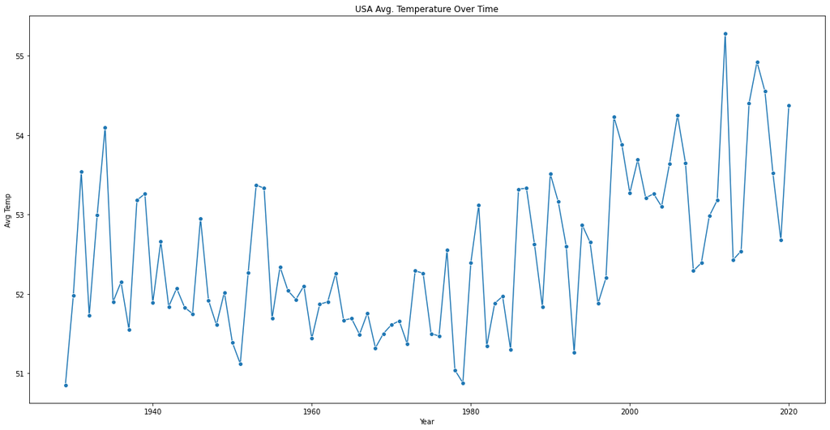

```python
#Plotting year vs average temp
plt.figure(figsize = (20, 10))
sns.lineplot(x="Year", y="Temp", marker="o", data=weather)

plt.title("USA Avg. Temperature Over Time")
plt.xlabel("Year")
plt.ylabel("Avg Temp")
plt.show()
```

From this lineplot, the U.S. average temperature appears to have a gradual increase although there are some fluctations. Some years, the temperature rises steeply and some other years, it drops.

In order to tell exactly if the trend is increasing, we will plot a regression line that shows exactly how much the temperature is expected to increase over time.

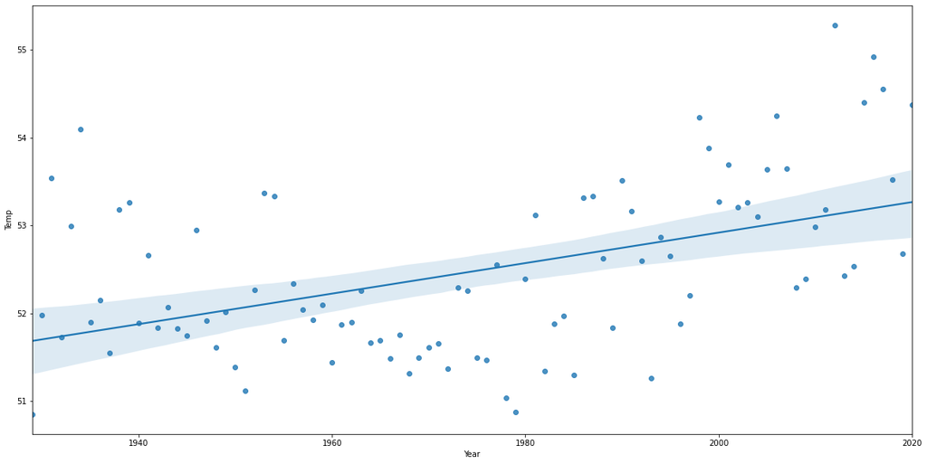

```python
#Plotting year vs average temp with regression line

plt.figure(figsize = (20, 10))
sns.regplot(x="Year", y="Temp", data=weather)
plt.show()
```

From our plot, we can see that there is an overall positively increasing trend of our weather data. From 1929 to 2020, the temperatures have increased despite some infrequent drops in temperature for a couple years. These results are consistent with our expectations, as we have expected an overall increase in average temperature.

As we did with our weather data, we will now create a line plot to visualize our GDP data over time.

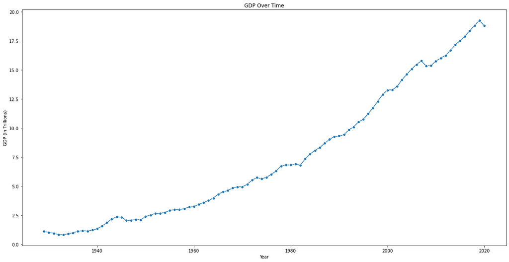

```python
#Plotting year vs GDP
plt.figure(figsize = (20, 10))
sns.lineplot(x="Year", y="GDP", marker="o", data=gdp)
plt.title("GDP Over Time")
plt.xlabel("Year")
plt.ylabel("GDP (In Trillions)")

plt.show()
```

As we can see from this plot, the GDP has a consistent increase over time. While the data from 1929 is below 2.5 trillion, by 2020 the GDP is nearly at 20 trillion.

A more accurate representation of this trend will now be displayed through a regression line of this data.

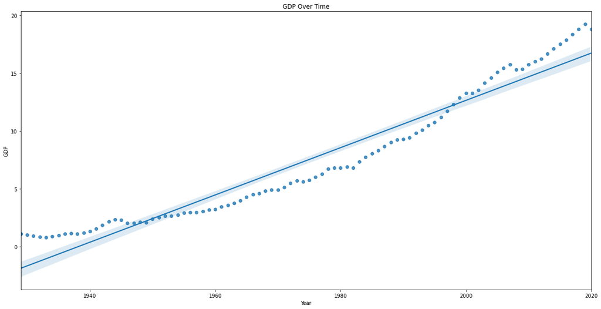

```python
#Plotting year vs GDP with regression line
plt.figure(figsize = (20, 10))
sns.regplot(x="Year", y="GDP", marker="o", data=gdp)
plt.title("GDP Over Time")
plt.xlabel("Year")
plt.ylabel("GDP")

plt.show()
```

From this model, we can see a clear positive linear trend of the GDP over time. This is also expected because the U.S. economy has grown significantly over the years.

## Exploratory Analysis

From our visualizations, we are curious about the exact numerical statistics of these trends. Our first objective in our exploratory analysis is to compare the rate at which weather and GDP increase over time. In order to find these finer details, we will have to import a new library that will give us this extra data. First, we will compare the slopes of the weather and the GDP data.

For this tutorial, we decided to use ols from the statsmodels.formula.api library. The ols().fit() function will allow us to obtain the ols regression results of our data, which includes the slope.

```python
from statsmodels.formula.api import ols

# Temp ~ Year in formula to compare temperature over year
weathertable = ols(formula = "Temp ~ Year", data = weather).fit()
weathertable.summary()
```

OLS Regression Results

| Dep. Variable: | Temp | R-squared: | 0.226 |
| --- | --- | --- | --- |
| Model: | OLS | Adj. R-squared: | 0.218 |
| Method: | Least Squares | F-statistic: | 26.31 |
| Date: | Sun, 16 May 2021 | Prob (F-statistic): | 1.66e-06 |
| Time: | 22:36:24 | Log-Likelihood: | -115.88 |
| No. Observations: | 92 | AIC: | 235.8 |
| Df Residuals: | 90 | BIC: | 240.8 |
| Df Model: | 1 |  |  |
| Covariance Type: | nonrobust |  |  |

|  | coef | std err | t | P>\|t\| | [0.025 | 0.975] |
| --- | --- | --- | --- | --- | --- | --- |
| Intercept | 18.2019 | 6.683 | 2.724 | 0.008 | 4.925 | 31.479 |
| Year | 0.0174 | 0.003 | 5.129 | 0.000 | 0.011 | 0.024 |

| Omnibus: | 4.047 | Durbin-Watson: | 1.285 |
| --- | --- | --- | --- |
| Prob(Omnibus): | 0.132 | Jarque-Bera (JB): | 3.995 |
| Skew: | 0.502 | Prob(JB): | 0.136 |
| Kurtosis: | 2.820 | Cond. No. | 1.47e+05 |

Notes:  
[1] Standard Errors assume that the covariance matrix of the errors is correctly specified.  
[2] The condition number is large, 1.47e+05. This might indicate that there are  
strong multicollinearity or other numerical problems.

```python
# GDP ~ Year in formula to compare GDP over years
gdptable = ols(formula = "GDP ~ Year", data = gdp).fit()
gdptable.summary()
```

OLS Regression Results

| Dep. Variable: | GDP | R-squared: | 0.938 |
| --- | --- | --- | --- |
| Model: | OLS | Adj. R-squared: | 0.937 |
| Method: | Least Squares | F-statistic: | 1361. |
| Date: | Sun, 16 May 2021 | Prob (F-statistic): | 3.99e-56 |
| Time: | 22:36:24 | Log-Likelihood: | -161.19 |
| No. Observations: | 92 | AIC: | 326.4 |
| Df Residuals: | 90 | BIC: | 331.4 |
| Df Model: | 1 |  |  |
| Covariance Type: | nonrobust |  |  |

|  | coef | std err | t | P>\|t\| | [0.025 | 0.975] |
| --- | --- | --- | --- | --- | --- | --- |
| Intercept | -396.0172 | 10.937 | -36.210 | 0.000 | -417.745 | -374.290 |
| Year | 0.2043 | 0.006 | 36.894 | 0.000 | 0.193 | 0.215 |

| Omnibus: | 37.942 | Durbin-Watson: | 0.022 |
| --- | --- | --- | --- |
| Prob(Omnibus): | 0.000 | Jarque-Bera (JB): | 7.385 |
| Skew: | 0.308 | Prob(JB): | 0.0249 |
| Kurtosis: | 1.756 | Cond. No. | 1.47e+05 |

Notes:  
[1] Standard Errors assume that the covariance matrix of the errors is correctly specified.  
[2] The condition number is large, 1.47e+05. This might indicate that there are  
strong multicollinearity or other numerical problems.

```python
tempslope = weathertable.params.Year
gdpslope = gdptable.params.Year
tempslope, gdpslope
```

```
(0.017358630149654164, 0.2043324907911164)
```

Through our ols().fit() function, we are now able to access the slopes of each data variable. We do this by accessing the Year variable in the params variable.

Now we can create a visual comparison between the GDP and the weather data. We do this by plotting both slopes from zero so that they are on the same starting point.

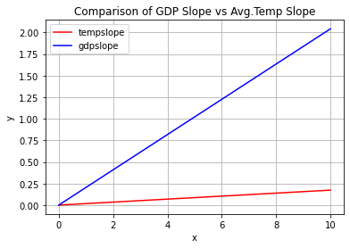

```python
x = np.linspace(0,10,100)

plt.plot(x, tempslope*x, '-r', label='tempslope')

plt.plot(x, gdpslope*x, '-b', label='gdpslope')

plt.title('Comparison of GDP Slope vs Avg.Temp Slope')
plt.xlabel('x')
plt.ylabel('y')
plt.legend(loc='upper left')
plt.grid()

plt.show()
```

As is shown from the graph, the GDP slope is much steeper compared to the weather slope. This shows that the GDP increases at a much faster rate compared to the temperature.

## Hypothesis Testing and Further Investigation

We chose to focus our hypothesis testing based on the Pearson correlation coefficient as opposed to the p-statistic. We came to this decision because the correlation coefficient provides a numerical value that indicates how strong the relationship between two variables in a dataframe are. This was our initial purpose for this investigation.  
Upon doing research on the correlation coefficient, we discovered that a correlation coefficient of .5 or more indicates a strong positive relationship. This will be the basis of our null and alternative hypotheses.  
H0: correlation coefficient < .5  
HA: correlation coefficient >= .5  
Thus, if there is no strong correlation between our two variables, our null hypothesis will be true.  
Source: https://machinelearningmastery.com/how-to-use-correlation-to-understand-the-relationship-between-variables/

To get our correlation matrix, we first need to combine our dataframes together.

```python
combined = weather[['Year', 'Temp']] # Create new data frame with the Year and Temp value from weather
combined['GDP'] = gdp["GDP"] # Add GDP values from GDP table.
combined.head()
```

|  | Year | Temp | GDP |
| --- | --- | --- | --- |
| 0 | 1929 | 50.85 | 1.11 |
| 1 | 1930 | 51.98 | 1.02 |
| 2 | 1931 | 53.54 | 0.95 |
| 3 | 1932 | 51.73 | 0.83 |
| 4 | 1933 | 52.99 | 0.82 |

Now, we have one table that holds our temperature and GDP values.  
From here, we can now create a correlation matrix to obtain the correlation coefficients between our variables.

```python
corr = combined.corr()
corr.style.background_gradient(cmap='coolwarm', axis=None)
```

|  | Year | Temp | GDP |
| --- | --- | --- | --- |
| Year | 1.000000 | 0.475584 | 0.968494 |
| Temp | 0.475584 | 1.000000 | 0.570620 |
| GDP | 0.968494 | 0.570620 | 1.000000 |

From this correlation matrix, we can see the correlation coefficient values between each pair of variables.  
Based on this matrix, we can reject our null hypothesis and accept the alternative hypothesis. The correlation coefficient between temperature and GDP is .570620. This means that our predication held true, however, it is not as strong of a relationship as we had expected. In fact, upon further investigation of the matrix, we can see that the coefficient between temperature and year is only .475584, while the coefficient between GDP and year is .968494. These results showed to be interesting because we expected there to be a stronger relationship with temperature and year.

We were not completely satisfied with these results as there might be underlying factors explaining this data. We determined that the weather correlation coefficient may not be as high because of variables that can be included in the data. As a result, we decided to examine one of these variables, such as population.

We first had to get the population data similarly to how we got our weather and GDP data.  
We got the data from this source: https://www.multpl.com/united-states-population/table/by-year  
From here, we copy and pasted the data into the text editor of our choice.  
In your text file, delete any entries that are before 1929 then save it as "population.csv".

```python
pop = pd.read_csv('population.csv', sep = '\t')
pop
```

|  | Dec 1, 2020 | 330.66 million |
| --- | --- | --- |
| 0 | Jul 1, 2020 | 329.88 million |
| 1 | Jul 1, 2019 | 328.24 million |
| 2 | Jul 1, 2018 | 326.69 million |
| 3 | Jul 1, 2017 | 324.99 million |
| 4 | Jul 1, 2016 | 322.94 million |
| ... | ... | ... |
| 87 | Jul 1, 1933 | 125.58 million |
| 88 | Jul 1, 1932 | 124.84 million |
| 89 | Jul 1, 1931 | 124.04 million |
| 90 | Jul 1, 1930 | 123.08 million |
| 91 | Jul 1, 1929 | 121.77 million |

92 rows × 2 columns

We will now need to tidy up the data.

```python
pop = pop.iloc[::-1].reset_index(drop=True) # Reversing our dataframe
pop.columns = ['Year', 'Pop'] # Rename the columns

for i, j in pop.iterrows():
    year = int(j[0][-4:])
    popNum = float(j[1][:-9])
    pop.at[i, 'Year'] = year
    pop.at[i, 'Pop'] = popNum

pop.Year = pop.Year.astype(int) # Making all numeric columns to int
pop.Pop = pop.Pop.astype(float) # Making all columns to float

pop
```

|  | Year | Pop |
| --- | --- | --- |
| 0 | 1929 | 121.7 |
| 1 | 1930 | 123.0 |
| 2 | 1931 | 124.0 |
| 3 | 1932 | 124.8 |
| 4 | 1933 | 125.5 |
| ... | ... | ... |
| 87 | 2016 | 322.9 |
| 88 | 2017 | 324.9 |
| 89 | 2018 | 326.6 |
| 90 | 2019 | 328.2 |
| 91 | 2020 | 329.8 |

92 rows × 2 columns

Now, we have a dataframe of U.S. population over years.

From here, we can add our the population data into our combined dataframe that we will use for our correlation matrix.

```python
combined["Pop"] = pop["Pop"]
combined.head()
```

|  | Year | Temp | GDP | Pop |
| --- | --- | --- | --- | --- |
| 0 | 1929 | 50.85 | 1.11 | 121.7 |
| 1 | 1930 | 51.98 | 1.02 | 123.0 |
| 2 | 1931 | 53.54 | 0.95 | 124.0 |
| 3 | 1932 | 51.73 | 0.83 | 124.8 |
| 4 | 1933 | 52.99 | 0.82 | 125.5 |

```python
corr = combined.corr()
corr.style.background_gradient(cmap='coolwarm', axis=None)
```

|  | Year | Temp | GDP | Pop |
| --- | --- | --- | --- | --- |
| Year | 1.000000 | 0.475584 | 0.968494 | 0.997353 |
| Temp | 0.475584 | 1.000000 | 0.570620 | 0.494279 |
| GDP | 0.968494 | 0.570620 | 1.000000 | 0.978989 |
| Pop | 0.997353 | 0.494279 | 0.978989 | 1.000000 |

Despite our findings, we were still surprised by our result for the temperature-population coefficient. As we can see from the table, we obtained a coefficient of 0.494279. While this is greater than the temperature-year coefficient, it is still not as high as we expected, however, we can see that GDP has a very strong relationship to population. This indicates that GDP and population are more intertwined than GDP and temperature.

We initially rejected our null hypothesis meaning that our beginning predictions were correct, however, upon this further investigation, we can see that GDP and Temperature as not as closely aligned as they might be with other variables that we did not consider.